Informe sobre la protección social y el trabajo en China Alexander Noblejas

# ÍNDICE

**1. Introducción y objetivos**  
**2. Desarrollo del análisis**  
**2.1 Promedio mundial de los indicadores en contraste con China**  
**2.2 Relación entre el Índice de Desarrollo Humano (IDH) y el porcentaje de empleadores por país**  
**2.3 Países según el nivel de empleo vulnerable**  
**2.4 Densidad de la población económicamente activa**  
**2.5 Frecuencia de los niveles de empleo vulnerable en el mundo**  
**3. Conclusiones**

# 1. ÍNTRODUCCIÓN Y OBJETIVOS

Actualmente ya no podemos desconocer el papel de nuestro país dentro del escenario internacional. China, junto con Rusia, hemos sido catalogados por la literatura occidental como una potencia revisionista, debido a que nuestra irrupción en el sistema internacional ha representado una amenaza para la posición hegemónica que por muchos años ha mantenido Estados Unidos. Sin embargo, también es necesario poder centrarnos en los procesos y fenómenos internos de nuestro estado, debido a que necesitamos tener un panorama más completo del desarrollo de China. Es a partir de ello que surge la necesidad de cuestionarnos sobre los avances en la calidad de vida de los ciudadanos en China, especialmente en el rubro laboral porque la industria de nuestro país a sido uno de nuestros más asertados avances.

Este reporte está dirigido a Oficina de estudios económicos y evaluaciones del Ministerio de Protección Social y el Trabajo para iniciar con el programa de políticas públicas basado en evidencia que se está impulsado desde el 2019. Este trabajo tiene como objetivo analizar los avances de China en materia de protección social y trabajo. De manera que podamos conocer si este rubro debo o no representar una de las prioridades del estado Chino. Para acercanos al panorama laborar del China, se ha seleccionado tres (03) indicadores: el porcentaje del empleadores, el porcentaje de empleo vulnerable y la población activa total. Estos se describen a continuación:

- **Empleadores, total (% del empleo total)**: Empleadores se refiere a aquellos trabajadores que, por cuenta propia o con unos pocos asociados, mantienen el tipo de trabajo que se define como “empleo por cuenta propia”, es decir: trabajos en los que la remuneración depende directamente de las utilidades derivadas de los bienes y servicios producidos, y que, en esta capacidad, han comprometido a una o más personas para trabajar con ellos como empleado(s) de manera continua. Fuente: Indicadores clave del mercado de trabajo ( KILM, por sus siglas en inglés ) de la OIT.
- **Empleo vulnerable, total (% del total de empleo)**: El empleo vulnerable se refiere a los trabajadores familiares no remunerados y a los trabajadores autónomos como porcentaje del empleo total.Fuente: Organización Internacional del Trabajo, base de datos de Indicadores principales sobre el mercado laboral.
- **Población activa, total**: La población activa total comprende a personas de 15 años o más que satisfacen la definición de la Organización Internacional del Trabajo de población económicamente activa: todas las personas que aportan trabajo para la producción de bienes y servicios durante un período específico. Incluye tanto a las personas con empleo como a las personas desempleadas. Si bien las prácticas nacionales varían en el tratamiento de grupos como las fuerzas armadas o los trabajadores estacionales o a tiempo parcial, en general, la población activa incluye a las fuerzas armadas, a los desempleados, a los que buscan su primer trabajo, pero excluye a quienes se dedican al cuidado del hogar y a otros trabajadores y cuidadores no remunerados. Fuente: Organización Internacional del Trabajo, base de datos de Indicadores principales sobre el mercado laboral.

# 2. DESARROLLO DEL ANÁLISIS

## 2.1 Promedio mundial de los indicadores en contraste con China (Tabla)

Para empezar con el análisis de la protección social y el trabajo en China, es importante conocer la ubicación de nuestro país en los indicadores seleccionados. Para ello, se promedia los valores de todos los estados de nuestra base de datos para luego contrastarlo con los valores de China en población económicamente activa, procentaje de empleadores y el índice de desarrollo humano.

```
##           PROMEDIO Promedio_Poblacionact Promedio_Empleadores Promedio_IDH
## 1 PROMEDIO MUNDIAL              21592922             3.360815    0.7330741
## 2            CHINA             800020955             2.110000    0.7610000
```

Como se puede observar en la TABLA, en promedio existen 21 592 922 personas economicamente activas en un país y China está muy por encima del promedio de población activa en el mundo. Asimismo, el promedio del porcentaje de empleasdores a nivel mundial es de 3.36, donde China está por debajo con 2.11. Para saber si esos resultados son indicadores positivos para el desarrollo de nuestro estado, es importante compararlo con el IDH. En promedio, el índice de desarrollo humano es de 0.73 en el mundo, donde China tiene un valor de 0.76.

Es releante resaltar que el valor del IDH de China está ligeramente por encima del promedio a nivel mundial. Sin embargo, en los siguientes analisis de los resultados veremos si ello corresponde al avance en temas de calidad del trabajo o si tenemos que extendernos a otros estudios para tener esa informacipon.

## 2.2 La relación del IDH con el procentanje de empleadores por país

Si aplicamos una correlación entre estas dos variables tendremos el siguiente resultado:

```
## [1] 0.3499156
```

Esto quiere decir que existe una relación pequeña entre ambas variables y que esta es positiva. Es decir, mientras más empleadores existen en un país, mejor será el índice de desarrollo humano. Para ver si los datos tiene ese comportamiento podemos mostrarun gráficos de dispersión de puntos:

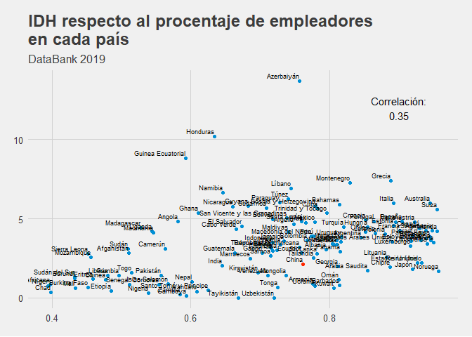

El gráfico confirma que existe esa relación pequeña entre el IDH y el procentaje de empleadores en cada páis. Asimismo, el gráfico nos da otros alcances porque podemos observar que los países con un índice de desarrollo humano muy alto -entre los más altos del mundo- como japón, Noruega, Suiza, Luxemburgo, entre otros,se concentran en el lado derecho inferior del gráfico y, contrarioa ello, los países africanos con menor IDH se ubican en la parte inferior izquierdo de la tabla. Esto nos indicaría que un mayor procentaje de empleadores en un país no necesariamente conduce a la mejora de la calidad de vida de las personas, sino que puede responder a la formalización y/o a otras formas de ingresar al empleo como aquellas que proporcionan los Estados.

## 2.3 Países según el nivel de empleo vulnerable

Se elaboró una variable categórica ordinal para que nos indique la categoría en la que podrían estar ubicados los países respecto a la protección social y el trabajo. En este caso se usó el indicador del “Empleo vulnerable” para hacer una variable categórica ordinal. De manera que nos indique por niveles qué paises tiene los porcetajes más elevando de empleos vulnerables respecto al empleo total; es decir, qué países tienen más o menos trabajadores familiares no remunerados y/o trabajadores autónomos como porcentaje del empleo total.

Respecto a lo mencionado, los trabajos no remunerados o que corresponden alguna vulnerabilidad económica para la persona tendría que tener relación con el Índice del Desarrollo Humano. Así como vimos que los países europeos y nórdicos se agruparon en el gráfico anterior, se espera que se refleje lo mismo respecto al empleo vulnerable (% del total del empleo) y que nos permita comprender los niveles de desarrollo de los países en función de la protección social y trabajo en cada uno de ellos, especialmente en China que es nuestro caso de mayor interés.

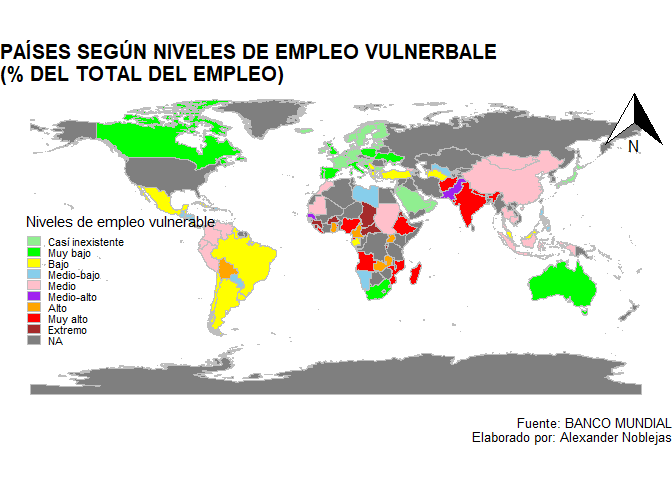

Como se puede observar en el MAPA DEL MUNDO, durante el 2019 los países europeos son los que tienen niveles más bajos en procentaje de empleo vulnerable. De acuerdo con los datos, el empleo vulnerable en estos países se ubica entre “casi inesxistente”, “muy bajo” o “bajo”; es decir, el empleo vulnerable no superar 31.5% del total en esos países. En contraste, en el continente africano apreciamos que allí se ubican los países con mayor porcentaje de empleo vulnerable, incluso en niveles de “extremo” que supera el 90% del total. Aunque es importante resaltar el caso atípico de Sudráfica que tiene un nivel de empleo vulnerable “muy bajo” (entre 10.6% y 21.1 %).

En cuanto a China, se observa que, al igual que varios países del continente asiático, se ubican en el nivel medio; es decir, los niveles de empleo vulnerable en China se encuentran entre el 42% y 52.5% del total. Asimismo, se evidencia que se trata de una característica más o menos recurrente en la región asiática oriental con tendencia reducir esos niveles.

Bajo el panorama mundial, el avance de China -potencia mundial- en temas de protección social y trabajo se encuentra a niveles similares que países en vías de desarrollo del continente Sudaméricano en casos como Perú, Ecuador y Colombia. Aunque también hay casos con mejores niveles que China, tales como Chile, Argentina, Uruguay y Brasil.

## 2.4 Densidad de la población económicamente activa

- Estadísticos descriptivos de la variable “Población activa”:

```
##      Min.   1st Qu.    Median      Mean   3rd Qu.      Max.
##     31687   1439472   4238924  21592922  13137960 800020955
```

Los estadísticos descriptivos nos indican que a nivel mundial existe una gran diferencia en la cantidad de población activa entre los países. Por un lado, se identifica a China como el país que más población económicamente activa tiene con un total de 800 020 955 personas. Por otro lado, se reconoce a Tonga como el país que menos población activa posee con un total de 31687 personas.

Asimismo, vemos que en promedio existen 21 592 922 personas economicamente activas entre los países del mundo. Lo que nos indica la importancia de seguir analizando este factor dentro de los países. Lo mencionado podemos verlo en un gráfico de densidad:

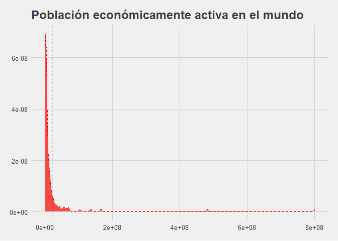

El grafico de densidad también nos muestra enorme la diferencia en cuanto al número de población económicamente activa en el mundo. Hay mucha más concetración de países cuyo número de población economicamente activa es menor a la del promedio mundial (21 592 922 personas), tal como indica la línea vertical. Más bien, existen una gran diferencia en cuanto a aquellos países como China, India y Estados Unidos (los tres países más importantes en la economía mundial) con una inmensa cantidad de población activa que superan los 160 millones de personas y aquellos que tiene muy poca como Tonga, Samo y San Vicente que no superan los 60 mil.

## 2.5 Frecuencia de los niveles de empleo vulnerable en el mundo

Es importante para este reporte contrastar la ubicación de China respecto a los niveles de empleo vulnerable, debido a que este indicador no se pudo incluir en el cuadro de promedios por ser una variable categórica ordinal. Primero observanos la distribución de manera numérica:

```
##
## Casi inexistente         Muy bajo             Bajo       Medio-bajo
##               28               21               23               14
##            Medio       Medio-alto             Alto         Muy alto
##               15                6                7               12
##          Extremo
##                9
```

Ahora creamos una gráfico de barras sobre la frecuencia de la variable en mención:

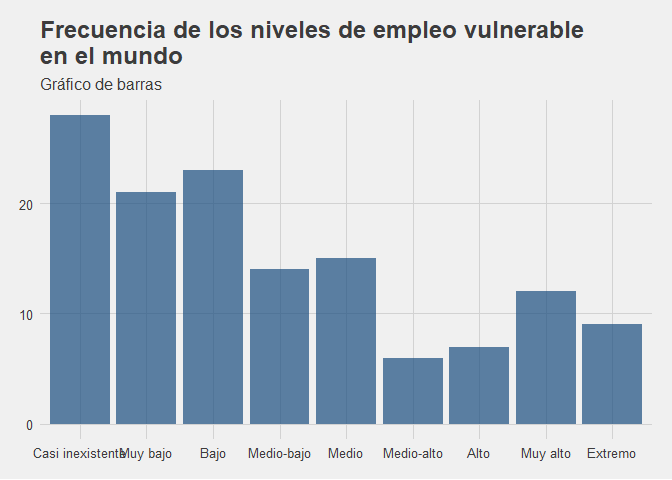

Asimismo, la distribución de los países en el gráfico indica que la mayor parte de los estados han avanzado respecto a la calidad de sus trabajos, dejando a China en un panorama intermedio. Esto no debería ser de esta manera si China quiere verse como un modelo a seguir y de gran influencia para la región asiática y le mundo.

# Conclusiones